# Tree-based method

Nina Li

May 29, 2019

source: [Quantative Geogrpahy](https://rspatial.org/raster/analysis/5-global_regression.html#google_vignette)

Load packages

```
## Checking rgeos availability: TRUE
```

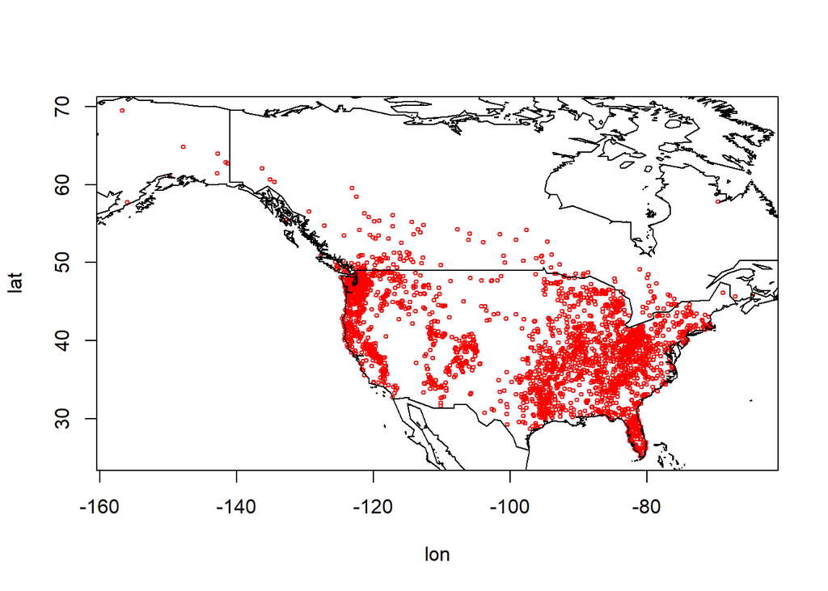

```r
bf <- sp_data('bigfoot')

plot(bf[,1:2], cex=0.5, col='red')
data(wrld_simpl)

plot(wrld_simpl, add=TRUE)
```

Predictors  
Precipitation and temperature are climatic predictors used as two predictors.  
In world climate raster file, bio1 is annual mean temperature(C). bio12 is annual precipitation.

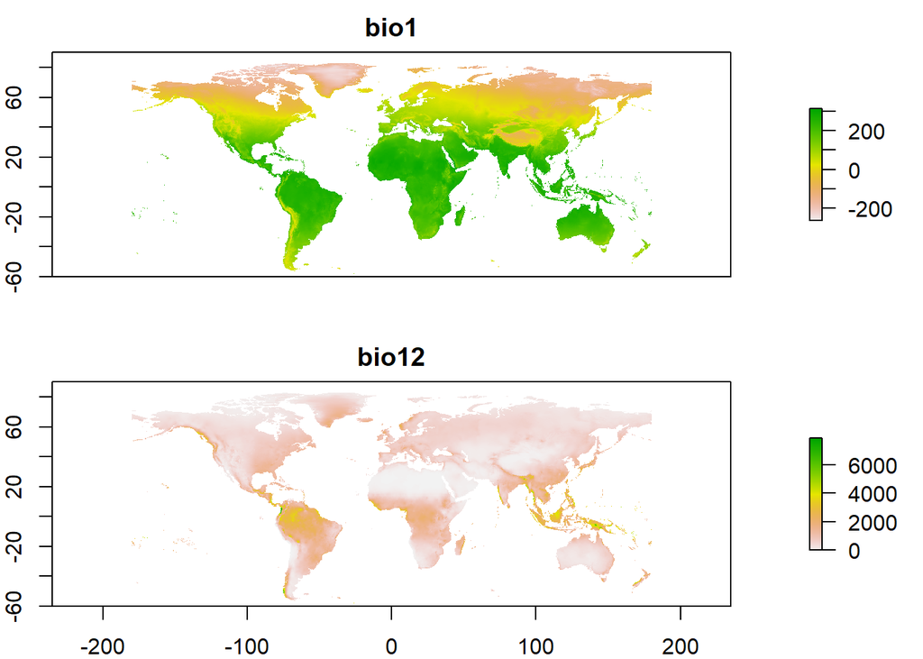

```r
wc <- raster::getData('worldclim', res=10, var='bio')

# plot two bio data
plot(wc[[c(1, 12)]], nr=2)
```

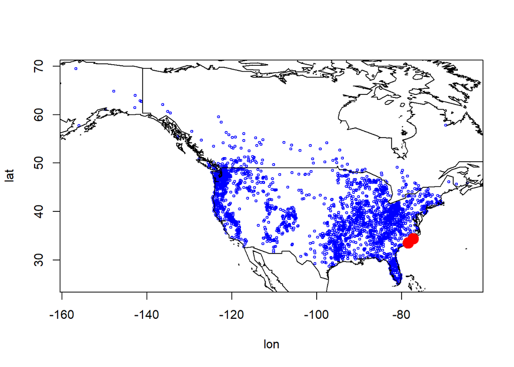

```r
bfc <- extract(wc, bf[,1:2])

# Any missing values?
i <- which(is.na(bfc[,1]))

plot(bf[,1:2], cex=0.5, col='blue')

plot(wrld_simpl, add=TRUE)

points(bf[i, ], pch=20, cex=3, col='red')
```

Background data  
To create climate data without knowning big foot exists or not.

```r
# extent of all points
e <- extent(SpatialPoints(bf[, 1:2]))

# 5000 random samples (excluding NA cells) from extent e
set.seed(0)
bg <- sampleRandom(wc, 5000, ext=e)

#combine presence and background data, pa = 1 is presence; pa = 0 is absence.
d <- rbind(cbind(pa=1, bfc), cbind(pa=0, bg))
d <- data.frame(d)

#split the data into east and west
de <- d[bf[,1] > -102, ]
dw <- d[bf[,1] <= -102, ]
```

Fit a model  
Classification and Regression Trees (CART) model

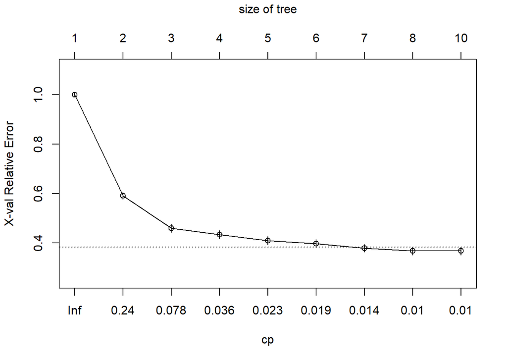

```r
cart <- rpart(pa~., data=dw)

printcp(cart)
##
## Regression tree:
## rpart(formula = pa ~ ., data = dw)
##
## Variables actually used in tree construction:
## [1] bio10 bio14 bio15 bio18 bio3  bio4  bio5  bio6  bio8
##
## Root node error: 762.45/3246 = 0.23489
##
## n= 3246
##
##         CP nsplit rel error  xerror     xstd
## 1 0.410197      0   1.00000 1.00071 0.008912
## 2 0.137588      1   0.58980 0.59037 0.014184
## 3 0.044259      2   0.45222 0.45958 0.016681
## 4 0.029121      3   0.40796 0.43353 0.016756
## 5 0.018954      4   0.37884 0.40941 0.016615
## 6 0.018324      5   0.35988 0.39714 0.016313
## 7 0.010113      6   0.34156 0.37834 0.015761
## 8 0.010008      7   0.33144 0.36700 0.016047
## 9 0.010000      9   0.31143 0.36700 0.016047
# CP is complexity parameter->control the size of decision tree
# if CP increases as the nsplit increases. The tree will stop growing.

plotcp(cart)
```

Here is the tree

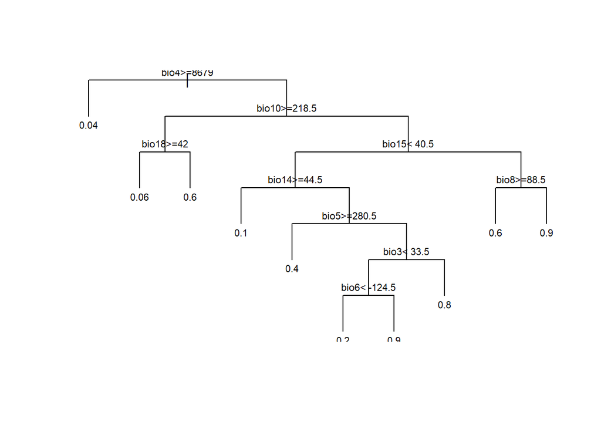

```r
plot(cart, uniform=TRUE)
# text(cart, use.n=TRUE, all=TRUE, cex=.8)
text(cart, cex=.7, digits=1)
```

Question 1  
Describe the conditions under which you have the highest probability of finding our beloved species?

The highest probability is 0.9. There are two highest probability.

Random Forest # Classification The plot below shows that as the increase of tree numbers, error rate was significantly reduced at the beginning, then reached a steady error rate no matther how many trees are trained.

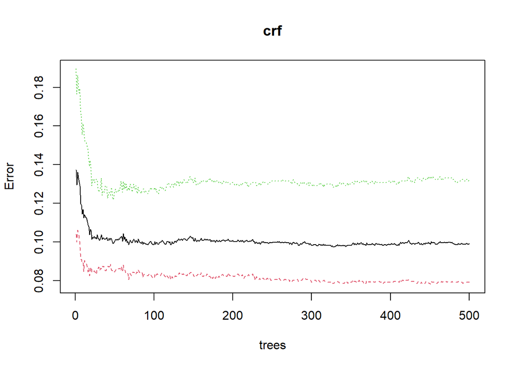

```r
# create a factor to indicated that we want classification
fpa <- as.factor(dw[, 'pa'])

#fit the random forest model
crf <- randomForest(dw[, 2:ncol(dw)], fpa)
crf
##
## Call:
##  randomForest(x = dw[, 2:ncol(dw)], y = fpa)
##                Type of random forest: classification
##                      Number of trees: 500
## No. of variables tried at each split: 4
##
##         OOB estimate of  error rate: 9.92%
## Confusion matrix:
##      0    1 class.error
## 0 1862  160  0.07912957
## 1  162 1062  0.13235294

plot(crf)
```

The variable importane plot shows which variables are most important in fitting the model.  
Gini index indicates the degree of impurity of the split. High Gini index indicates high impurity.  
Therefore, variables that cause high mean decrease in Gini indext rank top.

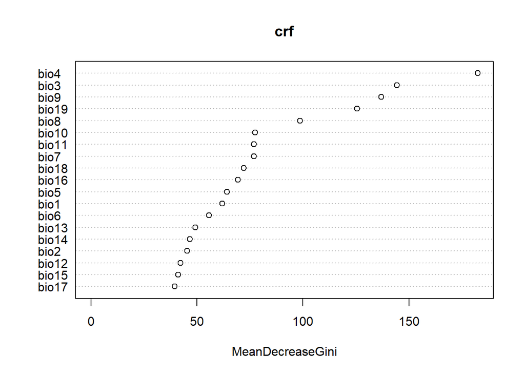

```r
varImpPlot(crf)
```

# Regression of Random Forest

Question 2: What did tuneRF help us find? What does the values of mt represent?

‘tuneRF’ helps to find the optimal value of variable number for randomForest.  
‘mt’ represents the number of variables that has the minimum error.  
In this case, it is 3.

```r
#tune the parameter and get the best variable number
trf <- tuneRF(dw[, 2:ncol(dw)], dw[, 'pa'])
```

```
## mtry = 6  OOB error = 0.07223543
## Searching left ...
## mtry = 3     OOB error = 0.07002109
## 0.03065438 0.05
## Searching right ...
## mtry = 12    OOB error = 0.07146042
## 0.01072891 0.05
```

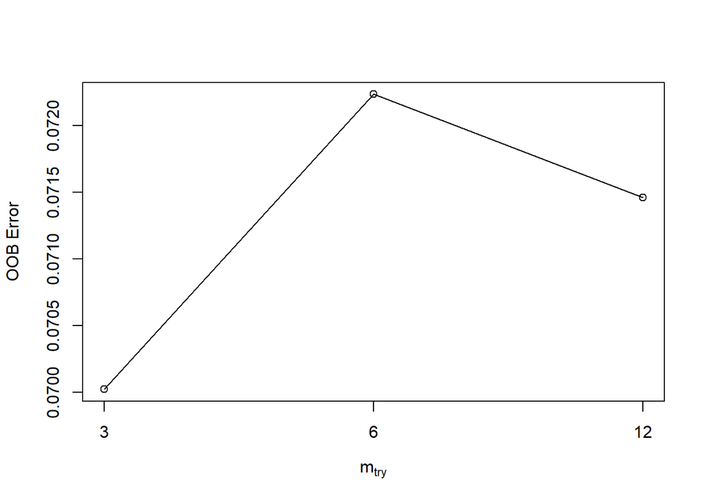

```r
mt <- trf[which.min(trf[,2]), 1]

mt
```

```
## [1] 3
```

Train regression tree

```r
rrf <- randomForest(dw[, 2:ncol(d)], dw[, 'pa'], mtry=mt)
```

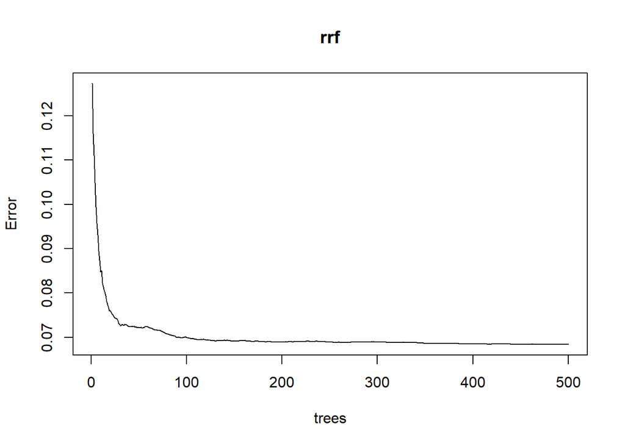

```r
plot(rrf)
```

x axis is increased node purity.

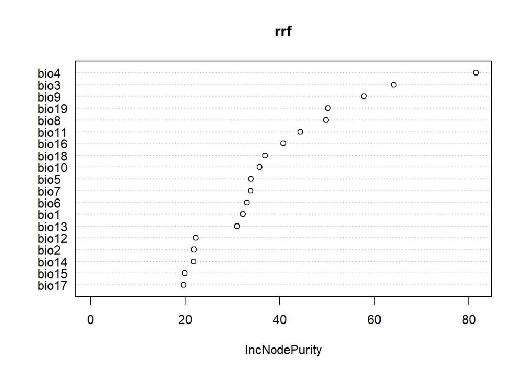

```r
varImpPlot(rrf)
```

Predict

```r
# Extent of the western points
ew <- extent(SpatialPoints(bf[bf[,1] <= -102, 1:2]))
```

Regression Here is our prediction based on the trained regression model.

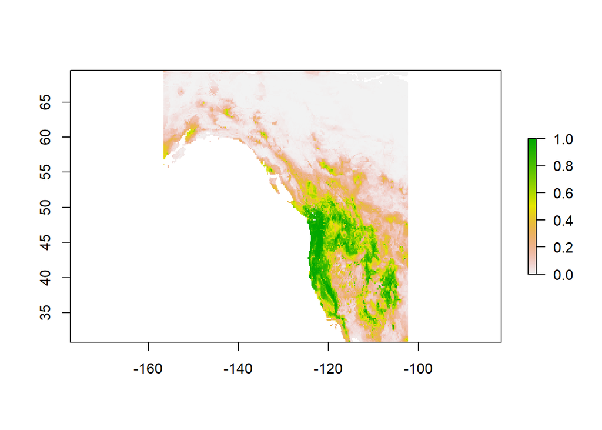

```r
rp <- predict(wc, rrf, ext=ew)
plot(rp)
```

To get the optimal threshold of deciding presence/absence, you would normally have a hold out data set, but here I used the training data for simplicity.

The plot below is the plot of Receiver Operating Characteristic curve (ROC curve). AUC is area under curve. If ROC is close to the top left corner, the accuracy of that threshold value is the best. If ROC is close to the right bottom corner, the accuracy is low.

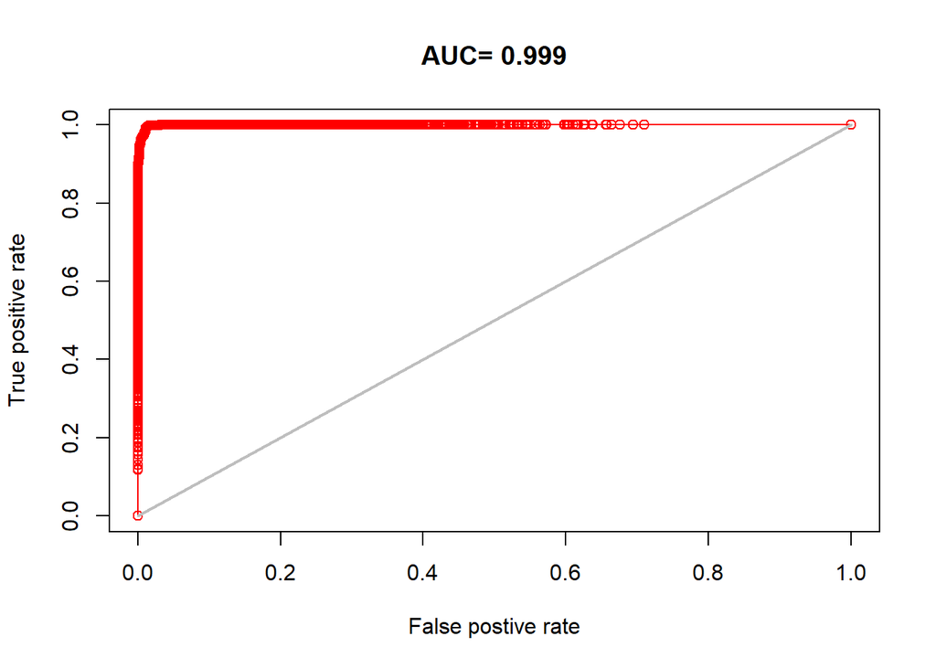

```r
# Cross-validation of models with presence/absence data.
eva <- evaluate(dw[dw$pa==1, ], dw[dw$pa==0, ], rrf)

plot(eva, 'ROC')
```

Get a threshold value to determine presence/absence and plot the prediction.  
Green area shows the presence of ‘bigfoot’.

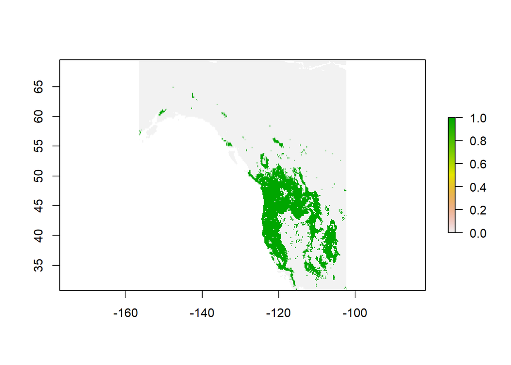

```r
tr <- threshold(eva)

plot(rp > tr[1, 'spec_sens'])
```

Classification

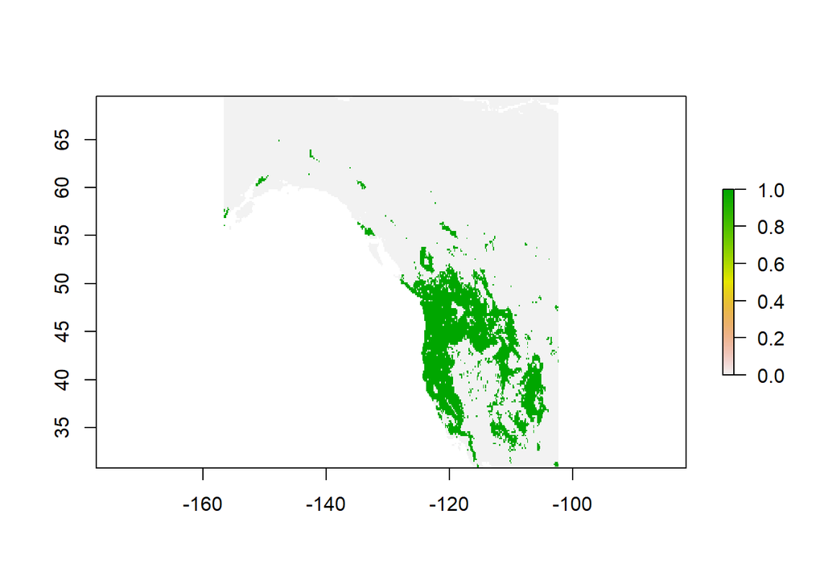

```r
rc <- predict(wc, crf, ext=ew)
plot(rc)
```

can also get probabilities for the classes

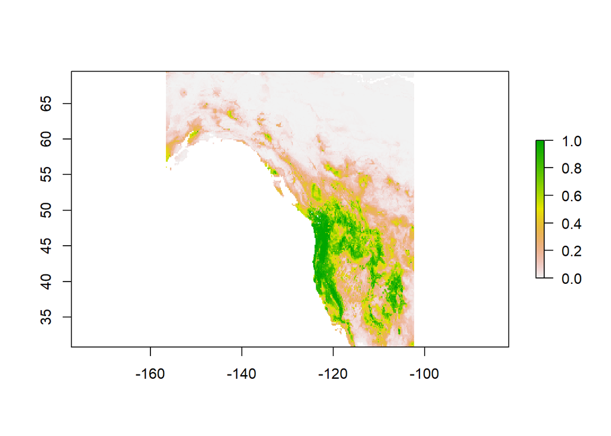

```r
rc2 <- predict(wc, crf, ext=ew, type='prob', index=2)
plot(rc2)
```

Extrapolation Making prediction with regression random forest model. The AUC plot show the model accuracy is low.

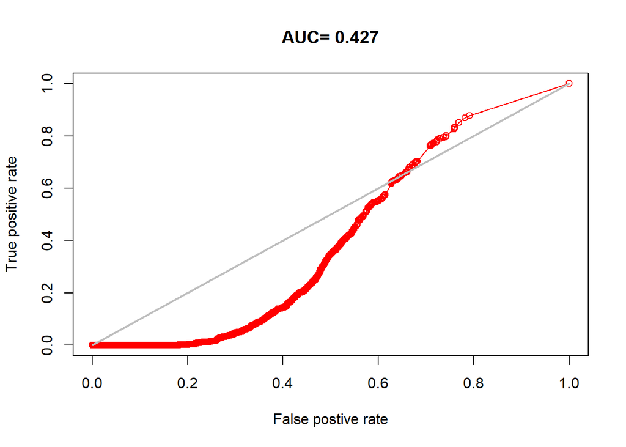

```r
de <- na.omit(de)
eva2 <- evaluate(de[de$pa==1, ], de[de$pa==0, ], rrf)

plot(eva2, 'ROC')
```

Take a look at it on a map.

Question 3: Why would it be that the model does not extrapolate well?

1. Training data is not comprehensive. The model is trained by the dw data. It didn’t include any data in the eastern US. Because the topography and climate in western area are quite different from each other. So it is possible the training data is not inclusive enough for the general prediction.
2. Overfitting. It is also possible that the number of variables are way more than needed which led the model fit the western region too well to be general.The tunning process also indicated that 3 is the optimal number of regression random forest.

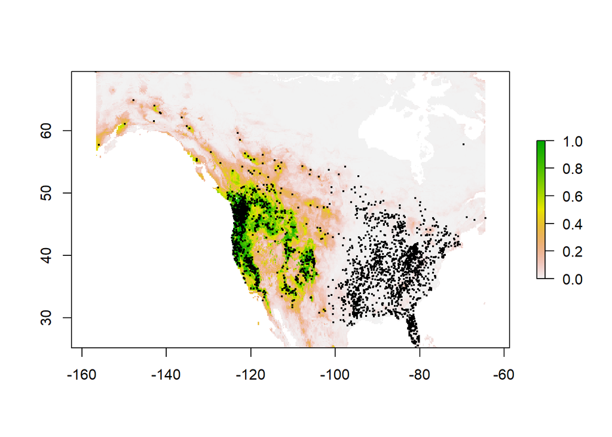

```r
eus <- extent(SpatialPoints(bf[, 1:2]))
rcusa <- predict(wc, rrf, ext=eus)
plot(rcusa)
points(bf[,1:2], cex=.25)
```

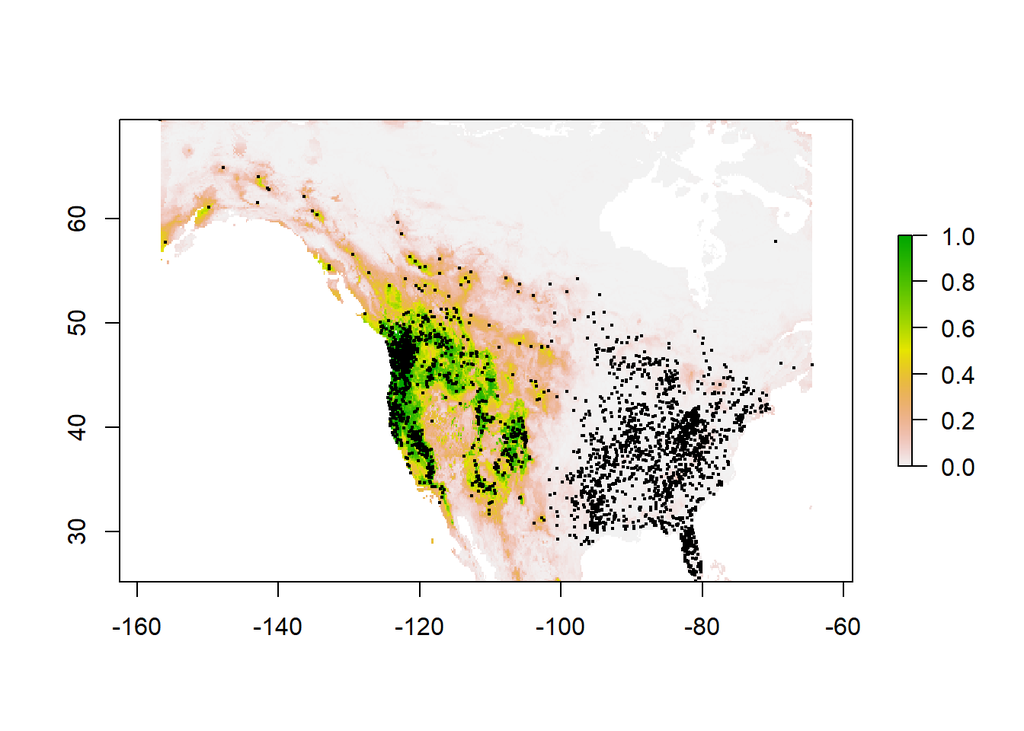

```r
de <- na.omit(de)
eva2 <- evaluate(de[de$pa==1, ], de[de$pa==0, ], rrf)
eus <- extent(SpatialPoints(bf[, 1:2]))
rcusa <- predict(wc, rrf, ext=eus)
plot(rcusa)
points(bf[,1:2], cex=.25)
```

Question 4: Make a map to show where conditions are improving for western bigfoot, and where they are not. Is the species headed toward extinction?

The species do not head toward exinction.  
Most of the area have variation smaller than zero as shown in the histgram which indicates that population of bigfoot increases in the future.

```r
#get the new climate data
fut <- getData('CMIP5', res=10, var='bio', rcp=85, model='AC', year=70)

#keep the column nama the same
names(fut) <- names(wc)

##extrapolate the spatial distribution of bigfoot with the new climate data
futusa <- predict(fut, rrf, ext=ew, progress='window')
```

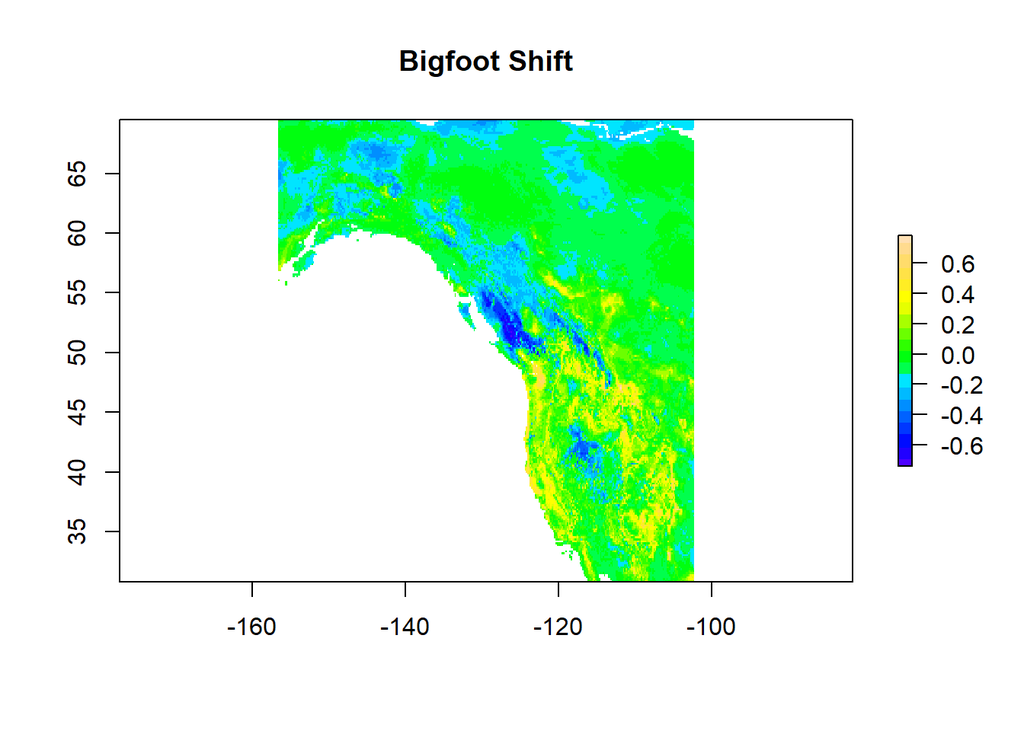

```r
#difference between occurence predicted by regression random forest -future
bd_dift <- rp-futusa

plot(bd_dift, col = topo.colors(20), main="Bigfoot Shift")
```

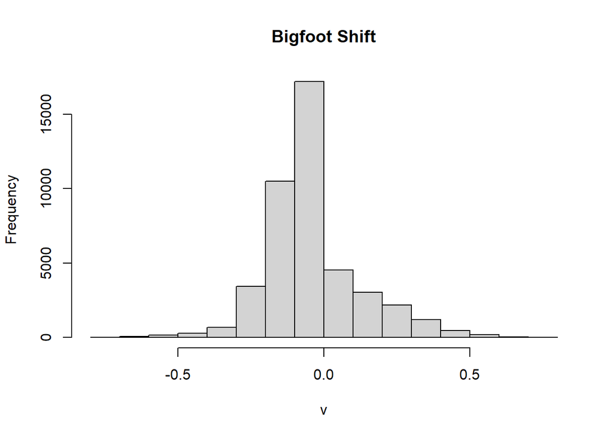

```r
##plot histogram on the variation data
hist(bd_dift, main="Bigfoot Shift")
```